# Risk Factor Analysis

## Outcome Variable

**Outcome Variable:** swasted

## Predictor Variables

**Intervention Variable:** enstunt

**Adjustment Set:**

- arm
- sex
- W_mage
- meducyrs
- feducyrs
- vagbrth
- single
- brthmon
- W_parity
- delta_W_mage
- delta_meducyrs
- delta_feducyrs
- delta_vagbrth
- delta_single
- delta_brthmon
- delta_W_parity

## Stratifying Variables

The analysis was stratified on these variable(s):

- agecat
- studyid
- country

## Data Summary

| agecat | studyid | country | enstunt | swasted | n_cell | n |
| --- | --- | --- | --- | --- | --- | --- |
| Birth | CMC-V-BCS-2002 | INDIA | 0 | 0 | 74 | 86 |
| Birth | CMC-V-BCS-2002 | INDIA | 0 | 1 | 0 | 86 |
| Birth | CMC-V-BCS-2002 | INDIA | 1 | 0 | 11 | 86 |
| Birth | CMC-V-BCS-2002 | INDIA | 1 | 1 | 1 | 86 |
| Birth | CMIN | BANGLADESH | 0 | 0 | 16 | 19 |
| Birth | CMIN | BANGLADESH | 0 | 1 | 1 | 19 |
| Birth | CMIN | BANGLADESH | 1 | 0 | 2 | 19 |
| Birth | CMIN | BANGLADESH | 1 | 1 | 0 | 19 |
| Birth | COHORTS | GUATEMALA | 0 | 0 | 672 | 756 |
| Birth | COHORTS | GUATEMALA | 0 | 1 | 60 | 756 |
| Birth | COHORTS | GUATEMALA | 1 | 0 | 24 | 756 |
| Birth | COHORTS | GUATEMALA | 1 | 1 | 0 | 756 |
| Birth | COHORTS | INDIA | 0 | 0 | 5514 | 6193 |
| Birth | COHORTS | INDIA | 0 | 1 | 299 | 6193 |
| Birth | COHORTS | INDIA | 1 | 0 | 359 | 6193 |
| Birth | COHORTS | INDIA | 1 | 1 | 21 | 6193 |
| Birth | COHORTS | PHILIPPINES | 0 | 0 | 2695 | 2899 |
| Birth | COHORTS | PHILIPPINES | 0 | 1 | 118 | 2899 |
| Birth | COHORTS | PHILIPPINES | 1 | 0 | 83 | 2899 |
| Birth | COHORTS | PHILIPPINES | 1 | 1 | 3 | 2899 |
| Birth | CONTENT | PERU | 0 | 0 | 2 | 2 |
| Birth | CONTENT | PERU | 0 | 1 | 0 | 2 |
| Birth | CONTENT | PERU | 1 | 0 | 0 | 2 |
| Birth | CONTENT | PERU | 1 | 1 | 0 | 2 |
| Birth | EE | PAKISTAN | 0 | 0 | 131 | 177 |
| Birth | EE | PAKISTAN | 0 | 1 | 6 | 177 |
| Birth | EE | PAKISTAN | 1 | 0 | 40 | 177 |
| Birth | EE | PAKISTAN | 1 | 1 | 0 | 177 |
| Birth | GMS-Nepal | NEPAL | 0 | 0 | 545 | 641 |
| Birth | GMS-Nepal | NEPAL | 0 | 1 | 25 | 641 |

[output cut: 298 more lines]

The following strata were considered:

- agecat: 24 months, studyid: CMC-V-BCS-2002, country: INDIA
- agecat: 24 months, studyid: CMIN, country: BANGLADESH
- agecat: 24 months, studyid: COHORTS, country: GUATEMALA
- agecat: 24 months, studyid: COHORTS, country: INDIA
- agecat: 24 months, studyid: COHORTS, country: PHILIPPINES
- agecat: 24 months, studyid: CONTENT, country: PERU
- agecat: 24 months, studyid: EE, country: PAKISTAN
- agecat: 24 months, studyid: GMS-Nepal, country: NEPAL
- agecat: 24 months, studyid: IRC, country: INDIA
- agecat: 24 months, studyid: JiVitA-3, country: BANGLADESH
- agecat: 24 months, studyid: JiVitA-4, country: BANGLADESH
- agecat: 24 months, studyid: Keneba, country: GAMBIA
- agecat: 24 months, studyid: LCNI-5, country: MALAWI
- agecat: 24 months, studyid: MAL-ED, country: BANGLADESH
- agecat: 24 months, studyid: MAL-ED, country: BRAZIL
- agecat: 24 months, studyid: MAL-ED, country: INDIA
- agecat: 24 months, studyid: MAL-ED, country: NEPAL
- agecat: 24 months, studyid: MAL-ED, country: PERU
- agecat: 24 months, studyid: MAL-ED, country: SOUTH AFRICA
- agecat: 24 months, studyid: MAL-ED, country: TANZANIA, UNITED REPUBLIC OF
- agecat: 24 months, studyid: NIH-Birth, country: BANGLADESH
- agecat: 24 months, studyid: NIH-Crypto, country: BANGLADESH
- agecat: 24 months, studyid: PROBIT, country: BELARUS
- agecat: 24 months, studyid: PROVIDE, country: BANGLADESH
- agecat: 24 months, studyid: TanzaniaChild2, country: TANZANIA, UNITED REPUBLIC OF
- agecat: 24 months, studyid: ZVITAMBO, country: ZIMBABWE
- agecat: 6 months, studyid: CMC-V-BCS-2002, country: INDIA
- agecat: 6 months, studyid: CMIN, country: BANGLADESH
- agecat: 6 months, studyid: COHORTS, country: GUATEMALA
- agecat: 6 months, studyid: COHORTS, country: INDIA
- agecat: 6 months, studyid: COHORTS, country: PHILIPPINES
- agecat: 6 months, studyid: CONTENT, country: PERU
- agecat: 6 months, studyid: EE, country: PAKISTAN
- agecat: 6 months, studyid: GMS-Nepal, country: NEPAL
- agecat: 6 months, studyid: Guatemala BSC, country: GUATEMALA
- agecat: 6 months, studyid: IRC, country: INDIA
- agecat: 6 months, studyid: JiVitA-3, country: BANGLADESH
- agecat: 6 months, studyid: JiVitA-4, country: BANGLADESH
- agecat: 6 months, studyid: Keneba, country: GAMBIA
- agecat: 6 months, studyid: LCNI-5, country: MALAWI
- agecat: 6 months, studyid: MAL-ED, country: BANGLADESH
- agecat: 6 months, studyid: MAL-ED, country: BRAZIL
- agecat: 6 months, studyid: MAL-ED, country: INDIA
- agecat: 6 months, studyid: MAL-ED, country: NEPAL
- agecat: 6 months, studyid: MAL-ED, country: PERU
- agecat: 6 months, studyid: MAL-ED, country: SOUTH AFRICA
- agecat: 6 months, studyid: MAL-ED, country: TANZANIA, UNITED REPUBLIC OF
- agecat: 6 months, studyid: NIH-Birth, country: BANGLADESH
- agecat: 6 months, studyid: NIH-Crypto, country: BANGLADESH
- agecat: 6 months, studyid: PROBIT, country: BELARUS
- agecat: 6 months, studyid: PROVIDE, country: BANGLADESH
- agecat: 6 months, studyid: ResPak, country: PAKISTAN
- agecat: 6 months, studyid: SAS-CompFeed, country: INDIA
- agecat: 6 months, studyid: SAS-FoodSuppl, country: INDIA
- agecat: 6 months, studyid: TanzaniaChild2, country: TANZANIA, UNITED REPUBLIC OF
- agecat: 6 months, studyid: ZVITAMBO, country: ZIMBABWE
- agecat: Birth, studyid: CMC-V-BCS-2002, country: INDIA
- agecat: Birth, studyid: CMIN, country: BANGLADESH
- agecat: Birth, studyid: COHORTS, country: GUATEMALA
- agecat: Birth, studyid: COHORTS, country: INDIA
- agecat: Birth, studyid: COHORTS, country: PHILIPPINES
- agecat: Birth, studyid: CONTENT, country: PERU
- agecat: Birth, studyid: EE, country: PAKISTAN
- agecat: Birth, studyid: GMS-Nepal, country: NEPAL
- agecat: Birth, studyid: IRC, country: INDIA
- agecat: Birth, studyid: JiVitA-3, country: BANGLADESH
- agecat: Birth, studyid: JiVitA-4, country: BANGLADESH
- agecat: Birth, studyid: Keneba, country: GAMBIA
- agecat: Birth, studyid: MAL-ED, country: BANGLADESH
- agecat: Birth, studyid: MAL-ED, country: BRAZIL
- agecat: Birth, studyid: MAL-ED, country: INDIA
- agecat: Birth, studyid: MAL-ED, country: NEPAL
- agecat: Birth, studyid: MAL-ED, country: PERU
- agecat: Birth, studyid: MAL-ED, country: SOUTH AFRICA
- agecat: Birth, studyid: MAL-ED, country: TANZANIA, UNITED REPUBLIC OF
- agecat: Birth, studyid: NIH-Birth, country: BANGLADESH
- agecat: Birth, studyid: NIH-Crypto, country: BANGLADESH
- agecat: Birth, studyid: PROBIT, country: BELARUS
- agecat: Birth, studyid: PROVIDE, country: BANGLADESH
- agecat: Birth, studyid: ResPak, country: PAKISTAN
- agecat: Birth, studyid: SAS-CompFeed, country: INDIA
- agecat: Birth, studyid: ZVITAMBO, country: ZIMBABWE

### Dropped Strata

Some strata were dropped due to rare outcomes:

- agecat: Birth, studyid: CMC-V-BCS-2002, country: INDIA
- agecat: Birth, studyid: CMIN, country: BANGLADESH
- agecat: Birth, studyid: COHORTS, country: GUATEMALA
- agecat: Birth, studyid: COHORTS, country: PHILIPPINES
- agecat: Birth, studyid: CONTENT, country: PERU
- agecat: Birth, studyid: EE, country: PAKISTAN
- agecat: Birth, studyid: GMS-Nepal, country: NEPAL
- agecat: Birth, studyid: IRC, country: INDIA
- agecat: Birth, studyid: Keneba, country: GAMBIA
- agecat: Birth, studyid: MAL-ED, country: BANGLADESH
- agecat: Birth, studyid: MAL-ED, country: BRAZIL
- agecat: Birth, studyid: MAL-ED, country: INDIA
- agecat: Birth, studyid: MAL-ED, country: NEPAL
- agecat: Birth, studyid: MAL-ED, country: PERU
- agecat: Birth, studyid: MAL-ED, country: SOUTH AFRICA
- agecat: Birth, studyid: MAL-ED, country: TANZANIA, UNITED REPUBLIC OF
- agecat: Birth, studyid: NIH-Crypto, country: BANGLADESH
- agecat: Birth, studyid: PROBIT, country: BELARUS
- agecat: Birth, studyid: PROVIDE, country: BANGLADESH
- agecat: Birth, studyid: ResPak, country: PAKISTAN
- agecat: 6 months, studyid: CMC-V-BCS-2002, country: INDIA
- agecat: 6 months, studyid: CMIN, country: BANGLADESH
- agecat: 6 months, studyid: COHORTS, country: GUATEMALA
- agecat: 6 months, studyid: COHORTS, country: PHILIPPINES
- agecat: 6 months, studyid: CONTENT, country: PERU
- agecat: 6 months, studyid: EE, country: PAKISTAN
- agecat: 6 months, studyid: GMS-Nepal, country: NEPAL
- agecat: 6 months, studyid: Guatemala BSC, country: GUATEMALA
- agecat: 6 months, studyid: IRC, country: INDIA
- agecat: 6 months, studyid: LCNI-5, country: MALAWI
- agecat: 6 months, studyid: MAL-ED, country: BANGLADESH
- agecat: 6 months, studyid: MAL-ED, country: BRAZIL
- agecat: 6 months, studyid: MAL-ED, country: INDIA
- agecat: 6 months, studyid: MAL-ED, country: NEPAL
- agecat: 6 months, studyid: MAL-ED, country: PERU
- agecat: 6 months, studyid: MAL-ED, country: SOUTH AFRICA
- agecat: 6 months, studyid: MAL-ED, country: TANZANIA, UNITED REPUBLIC OF
- agecat: 6 months, studyid: NIH-Birth, country: BANGLADESH
- agecat: 6 months, studyid: NIH-Crypto, country: BANGLADESH
- agecat: 6 months, studyid: PROBIT, country: BELARUS
- agecat: 6 months, studyid: PROVIDE, country: BANGLADESH
- agecat: 6 months, studyid: ResPak, country: PAKISTAN
- agecat: 6 months, studyid: TanzaniaChild2, country: TANZANIA, UNITED REPUBLIC OF
- agecat: 24 months, studyid: CMC-V-BCS-2002, country: INDIA
- agecat: 24 months, studyid: CMIN, country: BANGLADESH
- agecat: 24 months, studyid: COHORTS, country: GUATEMALA
- agecat: 24 months, studyid: COHORTS, country: PHILIPPINES
- agecat: 24 months, studyid: CONTENT, country: PERU
- agecat: 24 months, studyid: EE, country: PAKISTAN
- agecat: 24 months, studyid: GMS-Nepal, country: NEPAL
- agecat: 24 months, studyid: IRC, country: INDIA
- agecat: 24 months, studyid: Keneba, country: GAMBIA
- agecat: 24 months, studyid: LCNI-5, country: MALAWI
- agecat: 24 months, studyid: MAL-ED, country: BANGLADESH
- agecat: 24 months, studyid: MAL-ED, country: BRAZIL
- agecat: 24 months, studyid: MAL-ED, country: INDIA
- agecat: 24 months, studyid: MAL-ED, country: NEPAL
- agecat: 24 months, studyid: MAL-ED, country: PERU
- agecat: 24 months, studyid: MAL-ED, country: SOUTH AFRICA
- agecat: 24 months, studyid: MAL-ED, country: TANZANIA, UNITED REPUBLIC OF
- agecat: 24 months, studyid: NIH-Birth, country: BANGLADESH
- agecat: 24 months, studyid: NIH-Crypto, country: BANGLADESH
- agecat: 24 months, studyid: PROBIT, country: BELARUS
- agecat: 24 months, studyid: PROVIDE, country: BANGLADESH
- agecat: 24 months, studyid: TanzaniaChild2, country: TANZANIA, UNITED REPUBLIC OF

## Methods Detail

We’re interested in the causal parameters $E[Y_a]$ for all values of $a \in \mathcal{A}$. These parameters represent the mean outcome if, possibly contrary to fact, we intervened to set all units to have $A=a$. Under the randomization and positivity assumptions, these are identified by the statistical parameters $\psi_a=E_W[E_{Y|A,W}(Y|A=a,W)]$. In addition, we’re interested in the mean of $Y$, $E[Y]$ under no intervention (the observed mean). We will estimate these parameters by using SuperLearner to fit the relevant likelihood factors – $E_{Y|A,W}(Y|A=a,W)$ and $p(A=a|W)$, and then updating our likelihood fit using a joint TMLE.

For unadjusted analyses ($W=\{\}$), initial likelihoods were estimated using Lrnr_glm to estimate the simple $E(Y|A)$ and Lrnr_mean to estimate $p(A)$. For adjusted analyses, a small library containing Lrnr_glmnet, Lrnr_xgboost, and Lrnr_mean was used.

Having estimated these parameters, we will then use the delta method to estimate relative risks and attributable risks relative to a prespecified baseline level of $A$.

# Results Detail

## Results Plots

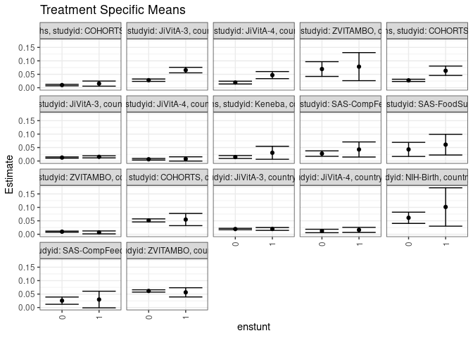

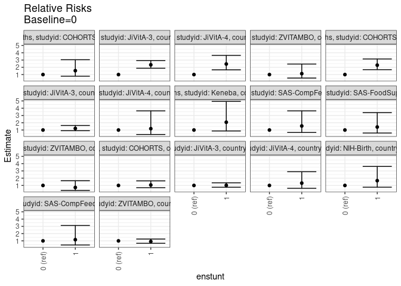

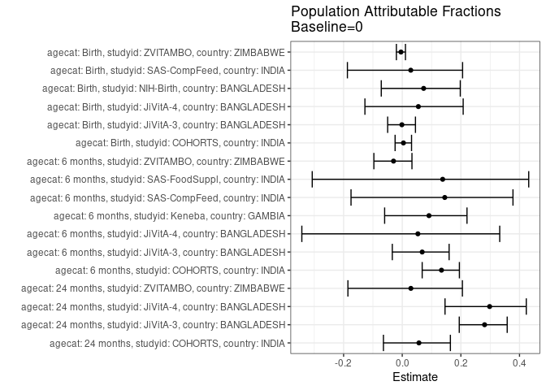

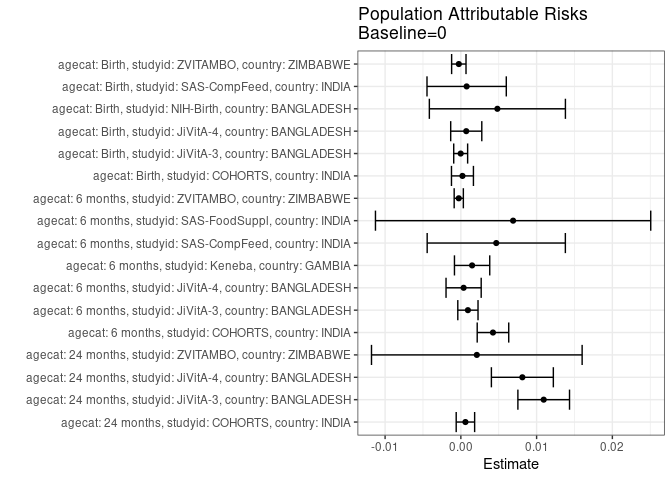

## Results Table

### Parameter: TSM

| agecat | studyid | country | intervention_level | baseline_level | estimate | ci_lower | ci_upper |
| --- | --- | --- | --- | --- | --- | --- | --- |
| Birth | COHORTS | INDIA | 0 | NA | 0.0514600 | 0.0457791 | 0.0571409 |
| Birth | COHORTS | INDIA | 1 | NA | 0.0546930 | 0.0320664 | 0.0773196 |
| Birth | JiVitA-3 | BANGLADESH | 0 | NA | 0.0193970 | 0.0167124 | 0.0220816 |
| Birth | JiVitA-3 | BANGLADESH | 1 | NA | 0.0196647 | 0.0143768 | 0.0249526 |
| Birth | JiVitA-4 | BANGLADESH | 0 | NA | 0.0122262 | 0.0059043 | 0.0185481 |
| Birth | JiVitA-4 | BANGLADESH | 1 | NA | 0.0161663 | 0.0068108 | 0.0255218 |
| Birth | NIH-Birth | BANGLADESH | 0 | NA | 0.0612648 | 0.0403513 | 0.0821784 |
| Birth | NIH-Birth | BANGLADESH | 1 | NA | 0.1014493 | 0.0301480 | 0.1727506 |
| Birth | SAS-CompFeed | INDIA | 0 | NA | 0.0255272 | 0.0120773 | 0.0389770 |
| Birth | SAS-CompFeed | INDIA | 1 | NA | 0.0297030 | -0.0011491 | 0.0605550 |
| Birth | ZVITAMBO | ZIMBABWE | 0 | NA | 0.0615829 | 0.0573210 | 0.0658448 |
| Birth | ZVITAMBO | ZIMBABWE | 1 | NA | 0.0564180 | 0.0392639 | 0.0735722 |
| 6 months | COHORTS | INDIA | 0 | NA | 0.0274399 | 0.0233125 | 0.0315673 |
| 6 months | COHORTS | INDIA | 1 | NA | 0.0630547 | 0.0456325 | 0.0804770 |
| 6 months | JiVitA-3 | BANGLADESH | 0 | NA | 0.0127716 | 0.0104359 | 0.0151073 |
| 6 months | JiVitA-3 | BANGLADESH | 1 | NA | 0.0154868 | 0.0115803 | 0.0193932 |
| 6 months | JiVitA-4 | BANGLADESH | 0 | NA | 0.0064636 | 0.0035705 | 0.0093568 |
| 6 months | JiVitA-4 | BANGLADESH | 1 | NA | 0.0076617 | -0.0001852 | 0.0155085 |
| 6 months | Keneba | GAMBIA | 0 | NA | 0.0147913 | 0.0093520 | 0.0202307 |
| 6 months | Keneba | GAMBIA | 1 | NA | 0.0306122 | 0.0064899 | 0.0547346 |
| 6 months | SAS-CompFeed | INDIA | 0 | NA | 0.0275594 | 0.0174097 | 0.0377090 |
| 6 months | SAS-CompFeed | INDIA | 1 | NA | 0.0428096 | 0.0147374 | 0.0708818 |
| 6 months | SAS-FoodSuppl | INDIA | 0 | NA | 0.0431034 | 0.0169358 | 0.0692711 |
| 6 months | SAS-FoodSuppl | INDIA | 1 | NA | 0.0608108 | 0.0222580 | 0.0993636 |
| 6 months | ZVITAMBO | ZIMBABWE | 0 | NA | 0.0095650 | 0.0073812 | 0.0117488 |
| 6 months | ZVITAMBO | ZIMBABWE | 1 | NA | 0.0068729 | 0.0013921 | 0.0123536 |
| 24 months | COHORTS | INDIA | 0 | NA | 0.0099815 | 0.0071216 | 0.0128415 |
| 24 months | COHORTS | INDIA | 1 | NA | 0.0153424 | 0.0058161 | 0.0248687 |
| 24 months | JiVitA-3 | BANGLADESH | 0 | NA | 0.0280029 | 0.0235702 | 0.0324356 |
| 24 months | JiVitA-3 | BANGLADESH | 1 | NA | 0.0656010 | 0.0553522 | 0.0758497 |
| 24 months | JiVitA-4 | BANGLADESH | 0 | NA | 0.0191237 | 0.0139371 | 0.0243104 |
| 24 months | JiVitA-4 | BANGLADESH | 1 | NA | 0.0469132 | 0.0337619 | 0.0600645 |
| 24 months | ZVITAMBO | ZIMBABWE | 0 | NA | 0.0694864 | 0.0420614 | 0.0969115 |
| 24 months | ZVITAMBO | ZIMBABWE | 1 | NA | 0.0784314 | 0.0261967 | 0.1306660 |

### Parameter: E(Y)

| agecat | studyid | country | intervention_level | baseline_level | estimate | ci_lower | ci_upper |
| --- | --- | --- | --- | --- | --- | --- | --- |
| Birth | COHORTS | INDIA | NA | NA | 0.0516712 | 0.0461576 | 0.0571849 |
| Birth | JiVitA-3 | BANGLADESH | NA | NA | 0.0193738 | 0.0169653 | 0.0217823 |
| Birth | JiVitA-4 | BANGLADESH | NA | NA | 0.0129382 | 0.0075150 | 0.0183614 |
| Birth | NIH-Birth | BANGLADESH | NA | NA | 0.0660870 | 0.0457632 | 0.0864107 |
| Birth | SAS-CompFeed | INDIA | NA | NA | 0.0262919 | 0.0122874 | 0.0402964 |
| Birth | ZVITAMBO | ZIMBABWE | NA | NA | 0.0613145 | 0.0571772 | 0.0654519 |
| 6 months | COHORTS | INDIA | NA | NA | 0.0316788 | 0.0275309 | 0.0358267 |
| 6 months | JiVitA-3 | BANGLADESH | NA | NA | 0.0137035 | 0.0116269 | 0.0157801 |
| 6 months | JiVitA-4 | BANGLADESH | NA | NA | 0.0068281 | 0.0038634 | 0.0097927 |
| 6 months | Keneba | GAMBIA | NA | NA | 0.0162757 | 0.0108484 | 0.0217031 |
| 6 months | SAS-CompFeed | INDIA | NA | NA | 0.0322339 | 0.0235219 | 0.0409459 |
| 6 months | SAS-FoodSuppl | INDIA | NA | NA | 0.0500000 | 0.0280580 | 0.0719420 |
| 6 months | ZVITAMBO | ZIMBABWE | NA | NA | 0.0092887 | 0.0072498 | 0.0113275 |
| 24 months | COHORTS | INDIA | NA | NA | 0.0105840 | 0.0078264 | 0.0133416 |
| 24 months | JiVitA-3 | BANGLADESH | NA | NA | 0.0389399 | 0.0346167 | 0.0432631 |
| 24 months | JiVitA-4 | BANGLADESH | NA | NA | 0.0272439 | 0.0220352 | 0.0324527 |
| 24 months | ZVITAMBO | ZIMBABWE | NA | NA | 0.0715935 | 0.0472820 | 0.0959051 |

### Parameter: RR

| agecat | studyid | country | intervention_level | baseline_level | estimate | ci_lower | ci_upper |
| --- | --- | --- | --- | --- | --- | --- | --- |
| Birth | COHORTS | INDIA | 0 | 0 | 1.0000000 | 1.0000000 | 1.000000 |
| Birth | COHORTS | INDIA | 1 | 0 | 1.0628251 | 0.6927124 | 1.630687 |
| Birth | JiVitA-3 | BANGLADESH | 0 | 0 | 1.0000000 | 1.0000000 | 1.000000 |
| Birth | JiVitA-3 | BANGLADESH | 1 | 0 | 1.0138014 | 0.7555089 | 1.360399 |
| Birth | JiVitA-4 | BANGLADESH | 0 | 0 | 1.0000000 | 1.0000000 | 1.000000 |
| Birth | JiVitA-4 | BANGLADESH | 1 | 0 | 1.3222671 | 0.6048868 | 2.890442 |
| Birth | NIH-Birth | BANGLADESH | 0 | 0 | 1.0000000 | 1.0000000 | 1.000000 |
| Birth | NIH-Birth | BANGLADESH | 1 | 0 | 1.6559140 | 0.7580633 | 3.617179 |
| Birth | SAS-CompFeed | INDIA | 0 | 0 | 1.0000000 | 1.0000000 | 1.000000 |
| Birth | SAS-CompFeed | INDIA | 1 | 0 | 1.1635816 | 0.4343503 | 3.117120 |
| Birth | ZVITAMBO | ZIMBABWE | 0 | 0 | 1.0000000 | 1.0000000 | 1.000000 |
| Birth | ZVITAMBO | ZIMBABWE | 1 | 0 | 0.9161315 | 0.6706955 | 1.251383 |
| 6 months | COHORTS | INDIA | 0 | 0 | 1.0000000 | 1.0000000 | 1.000000 |
| 6 months | COHORTS | INDIA | 1 | 0 | 2.2979223 | 1.6777242 | 3.147387 |
| 6 months | JiVitA-3 | BANGLADESH | 0 | 0 | 1.0000000 | 1.0000000 | 1.000000 |
| 6 months | JiVitA-3 | BANGLADESH | 1 | 0 | 1.2125903 | 0.9041744 | 1.626207 |
| 6 months | JiVitA-4 | BANGLADESH | 0 | 0 | 1.0000000 | 1.0000000 | 1.000000 |
| 6 months | JiVitA-4 | BANGLADESH | 1 | 0 | 1.1853532 | 0.3863374 | 3.636878 |
| 6 months | Keneba | GAMBIA | 0 | 0 | 1.0000000 | 1.0000000 | 1.000000 |
| 6 months | Keneba | GAMBIA | 1 | 0 | 2.0696064 | 0.8674280 | 4.937898 |
| 6 months | SAS-CompFeed | INDIA | 0 | 0 | 1.0000000 | 1.0000000 | 1.000000 |
| 6 months | SAS-CompFeed | INDIA | 1 | 0 | 1.5533589 | 0.6634013 | 3.637201 |
| 6 months | SAS-FoodSuppl | INDIA | 0 | 0 | 1.0000000 | 1.0000000 | 1.000000 |
| 6 months | SAS-FoodSuppl | INDIA | 1 | 0 | 1.4108108 | 0.5864839 | 3.393763 |
| 6 months | ZVITAMBO | ZIMBABWE | 0 | 0 | 1.0000000 | 1.0000000 | 1.000000 |
| 6 months | ZVITAMBO | ZIMBABWE | 1 | 0 | 0.7185426 | 0.3134818 | 1.646996 |
| 24 months | COHORTS | INDIA | 0 | 0 | 1.0000000 | 1.0000000 | 1.000000 |
| 24 months | COHORTS | INDIA | 1 | 0 | 1.5370837 | 0.7758247 | 3.045309 |
| 24 months | JiVitA-3 | BANGLADESH | 0 | 0 | 1.0000000 | 1.0000000 | 1.000000 |
| 24 months | JiVitA-3 | BANGLADESH | 1 | 0 | 2.3426478 | 1.8746623 | 2.927460 |
| 24 months | JiVitA-4 | BANGLADESH | 0 | 0 | 1.0000000 | 1.0000000 | 1.000000 |
| 24 months | JiVitA-4 | BANGLADESH | 1 | 0 | 2.4531404 | 1.6531165 | 3.640335 |
| 24 months | ZVITAMBO | ZIMBABWE | 0 | 0 | 1.0000000 | 1.0000000 | 1.000000 |
| 24 months | ZVITAMBO | ZIMBABWE | 1 | 0 | 1.1287298 | 0.5204485 | 2.447948 |

### Parameter: PAR

| agecat | studyid | country | intervention_level | baseline_level | estimate | ci_lower | ci_upper |
| --- | --- | --- | --- | --- | --- | --- | --- |
| Birth | COHORTS | INDIA | 0 | NA | 0.0002112 | -0.0012378 | 0.0016603 |
| Birth | JiVitA-3 | BANGLADESH | 0 | NA | -0.0000232 | -0.0009417 | 0.0008953 |
| Birth | JiVitA-4 | BANGLADESH | 0 | NA | 0.0007120 | -0.0013405 | 0.0027646 |
| Birth | NIH-Birth | BANGLADESH | 0 | NA | 0.0048221 | -0.0041582 | 0.0138025 |
| Birth | SAS-CompFeed | INDIA | 0 | NA | 0.0007647 | -0.0044690 | 0.0059985 |
| Birth | ZVITAMBO | ZIMBABWE | 0 | NA | -0.0002684 | -0.0012178 | 0.0006810 |
| 6 months | COHORTS | INDIA | 0 | NA | 0.0042389 | 0.0021584 | 0.0063194 |
| 6 months | JiVitA-3 | BANGLADESH | 0 | NA | 0.0009319 | -0.0004025 | 0.0022663 |
| 6 months | JiVitA-4 | BANGLADESH | 0 | NA | 0.0003644 | -0.0019558 | 0.0026847 |
| 6 months | Keneba | GAMBIA | 0 | NA | 0.0014844 | -0.0008441 | 0.0038129 |
| 6 months | SAS-CompFeed | INDIA | 0 | NA | 0.0046745 | -0.0044457 | 0.0137948 |
| 6 months | SAS-FoodSuppl | INDIA | 0 | NA | 0.0068966 | -0.0112717 | 0.0250648 |
| 6 months | ZVITAMBO | ZIMBABWE | 0 | NA | -0.0002763 | -0.0008822 | 0.0003295 |
| 24 months | COHORTS | INDIA | 0 | NA | 0.0006025 | -0.0006143 | 0.0018193 |
| 24 months | JiVitA-3 | BANGLADESH | 0 | NA | 0.0109370 | 0.0075295 | 0.0143444 |
| 24 months | JiVitA-4 | BANGLADESH | 0 | NA | 0.0081202 | 0.0040315 | 0.0122089 |
| 24 months | ZVITAMBO | ZIMBABWE | 0 | NA | 0.0021071 | -0.0117951 | 0.0160093 |

### Parameter: PAF

| agecat | studyid | country | intervention_level | baseline_level | estimate | ci_lower | ci_upper |
| --- | --- | --- | --- | --- | --- | --- | --- |
| Birth | COHORTS | INDIA | 0 | NA | 0.0040876 | -0.0243518 | 0.0317374 |
| Birth | JiVitA-3 | BANGLADESH | 0 | NA | -0.0011979 | -0.0497294 | 0.0450898 |
| Birth | JiVitA-4 | BANGLADESH | 0 | NA | 0.0550343 | -0.1272582 | 0.2078477 |
| Birth | NIH-Birth | BANGLADESH | 0 | NA | 0.0729665 | -0.0715119 | 0.1979640 |
| Birth | SAS-CompFeed | INDIA | 0 | NA | 0.0290865 | -0.1870240 | 0.2058517 |
| Birth | ZVITAMBO | ZIMBABWE | 0 | NA | -0.0043769 | -0.0199784 | 0.0109860 |
| 6 months | COHORTS | INDIA | 0 | NA | 0.1338100 | 0.0680253 | 0.1949512 |
| 6 months | JiVitA-3 | BANGLADESH | 0 | NA | 0.0680038 | -0.0339264 | 0.1598852 |
| 6 months | JiVitA-4 | BANGLADESH | 0 | NA | 0.0533736 | -0.3424503 | 0.3324881 |
| 6 months | Keneba | GAMBIA | 0 | NA | 0.0912029 | -0.0600361 | 0.2208641 |
| 6 months | SAS-CompFeed | INDIA | 0 | NA | 0.1450189 | -0.1746753 | 0.3777067 |
| 6 months | SAS-FoodSuppl | INDIA | 0 | NA | 0.1379310 | -0.3069960 | 0.4313962 |
| 6 months | ZVITAMBO | ZIMBABWE | 0 | NA | -0.0297498 | -0.0967403 | 0.0331487 |
| 24 months | COHORTS | INDIA | 0 | NA | 0.0569252 | -0.0641565 | 0.1642299 |
| 24 months | JiVitA-3 | BANGLADESH | 0 | NA | 0.2808685 | 0.1944736 | 0.3579974 |
| 24 months | JiVitA-4 | BANGLADESH | 0 | NA | 0.2980551 | 0.1459034 | 0.4231020 |
| 24 months | ZVITAMBO | ZIMBABWE | 0 | NA | 0.0294318 | -0.1852710 | 0.2052429 |